# Term1Prj4_Writeup

## Term 1 Project 4 : Advanced Lane Finding

### Project Writeup

**Advanced Lane Finding Project**

The goals / steps of this project are the following:

- Compute the camera calibration matrix and distortion coefficients given a set of chessboard images.
- Apply a distortion correction to raw images.
- Use color transforms, gradients, etc., to create a thresholded binary image.
- Apply a perspective transform to rectify binary image ("birds-eye view").
- Detect lane pixels and fit to find the lane boundary.
- Determine the curvature of the lane and vehicle position with respect to center.
- Warp the detected lane boundaries back onto the original image.
- Output visual display of the lane boundaries and numerical estimation of lane curvature and vehicle position.

### Files Submitted & Code Quality

My project includes the following files:

| File Name | Purpose |
| --- | --- |
| Advanced Lane Finding.ipynb | Jupyter notebook file that contains all the code with outputs |
| Term1Prj4_Writeup.html | Writeup document explains various features of the code and displays output |
| project_video_processed.mp4 | Processed videos that highlights the current lane |
| README.md | README file for setting up this project |

#### Rubric Points

Here I will consider the [rubric points](https://review.udacity.com/#!/rubrics/571/view) individually and describe how I addressed each point in my implementation

## Camera Calibration

Camera lens introduces distortion at the edges, hence you find the ends of images to be slighly out of sync with the real world. It is important to correct this distortion as this might affect the calculations and decisions taken based on those calculations.

Camera Calibration is done by using images taken with the camera that has specific clearly defined points like in the case of a chess board. Even in this case, I calibrated the camera using sample images provided that were taken with this camera

Calibration is done using OpenCV **calibrateCamera** function

Calibration returns the distortion co-efficients, distortion matrix. These can be used later to undistort the images. Since Calibration is computationally intensive, the distortion co-efficients and matrix are saved to a Pickle

I start by preparing "object points", which will be the (x, y, z) coordinates of the chessboard corners in the world. Here I am assuming the chessboard is fixed on the (x, y) plane at z=0, such that the object points are the same for each calibration image. Thus, objp is just a replicated array of coordinates, and objpoints will be appended with a copy of it every time I successfully detect all chessboard corners in a test image. imgpoints will be appended with the (x, y) pixel position of each of the corners in the image plane with each successful chessboard detection.

I then used the output objpoints and imgpoints to compute the camera calibration and distortion coefficients using the cv2.calibrateCamera() function. I applied this distortion correction to the test image using the cv2.undistort() function and obtained this result:

### Displaying Output : Camera Calibration

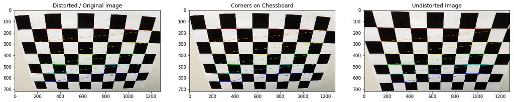

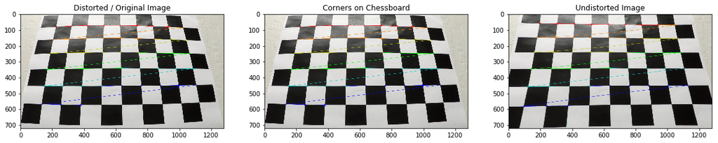

### Displaying Output : Undistorted Images

The camera matrix and distortion co-efficients obtained in the above process are used to correct the distorted images using OpenCV **undistort** function

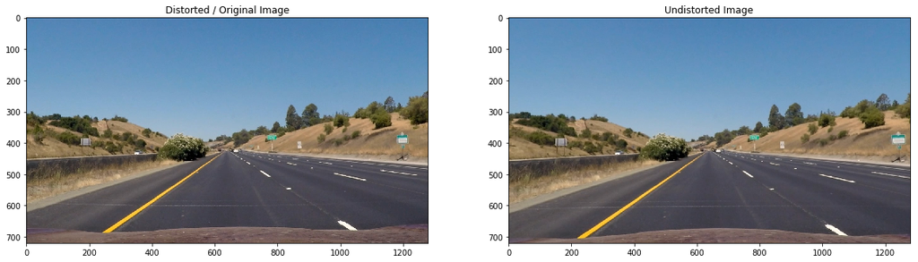

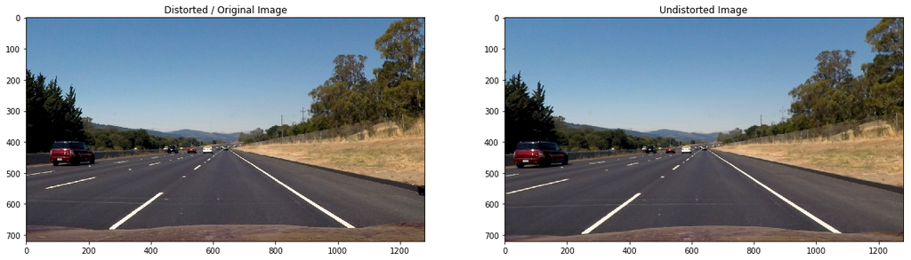

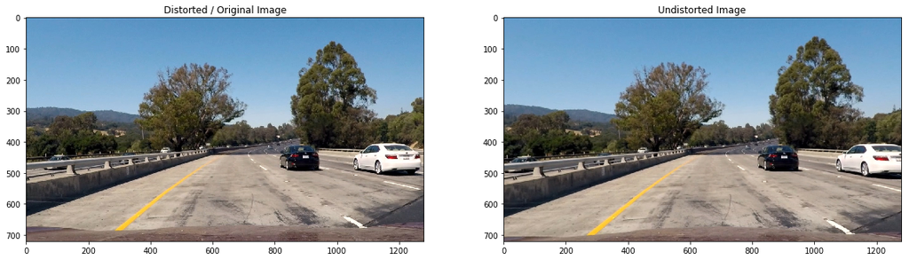

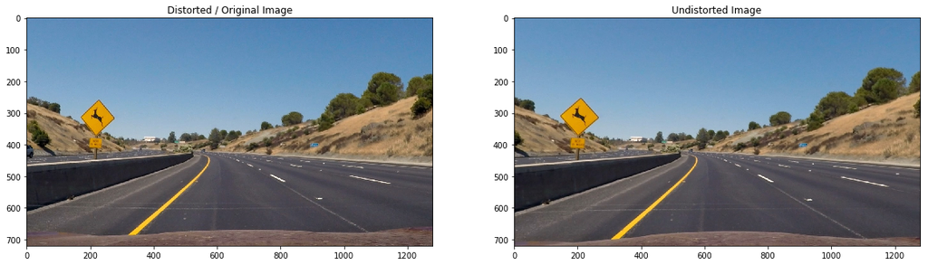

## Pre-Processing

It is a good practice to pre-process the images before determining the Lane Lines This is bacause we want to filter out unwanted data and enhance the required features of the image to better classify the edges and determine the Lines.

Following pre-processing techniques are used in my pre-processing pipeline

- Sobel along X & Y Axis
- Magnitude Threshold
- Direction Threshold
- Extracting the 'Saturation' Channel from HLS Color space makes the evaluation independent to the lighting conditions

Once the above pre-processing are done, these are combined in the following way to get the resulting image

**(SobelX & Sobel Y) OR (Magnitude Threshold & Direction Threshold) OR (Saturation Space)**

### Displaying Output : Gradient & Color Thresholds

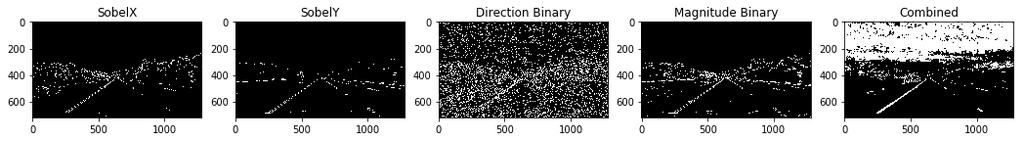

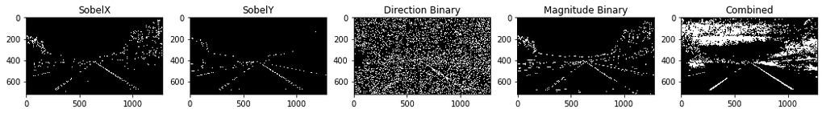

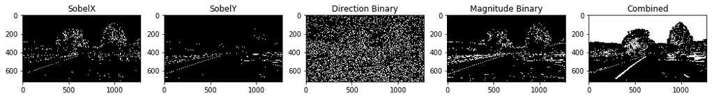

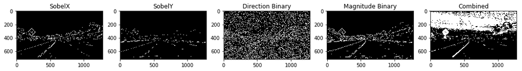

## Region of Interest

We don't require the complete image to evaluate the Lane Lines. We just have to consider our own lane which will be of our interest. Hence create a mask in the form of a trapeziod along the current lane and determine the thresholded Image along this region

### Displaying Output : Region of Interest

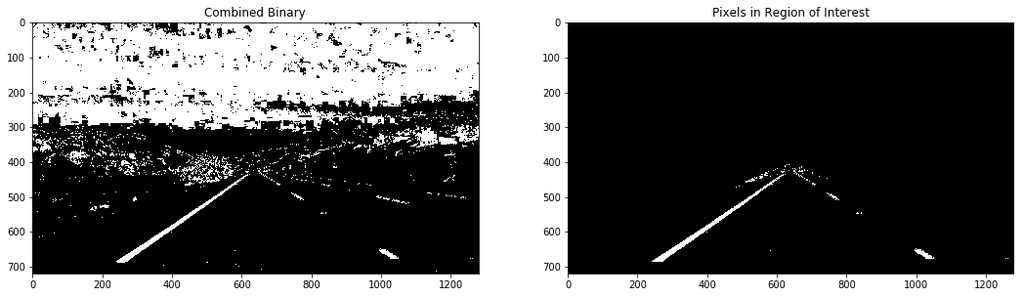

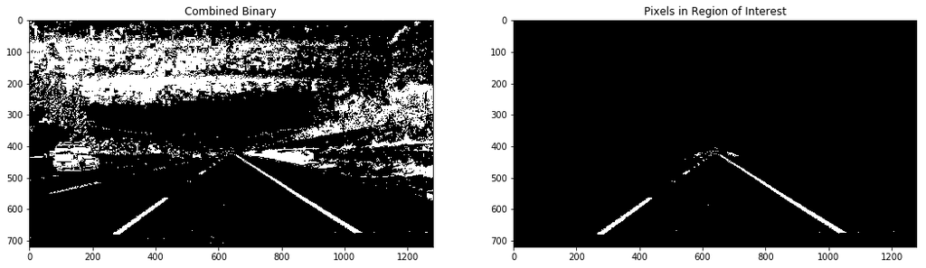

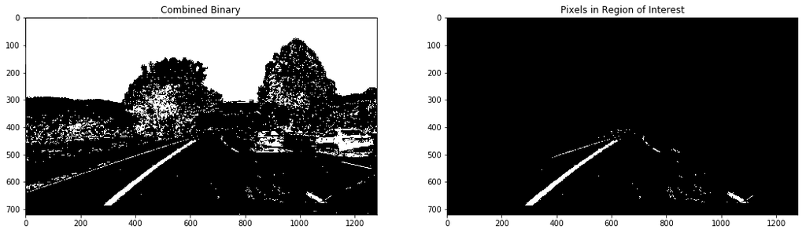

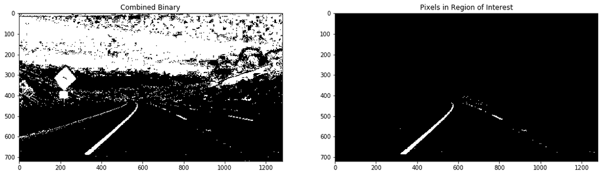

## Perspective Transformation

Lane Lines in fact are parallel but when you look the lane lines, they appear to be converging. THis is because of the perspective from which you are looking at the Lanes. If you look from a Bird Eye's view, the Lane Lines appear parallel. This is what we'll do next using the OpenCV's **getPerspectiveTransform**

In order to do this, we will map the image points in the image view to object points in the 2D space which forms the Bird Eye's view

Here are my source to destination point mapping from 3D Image space to 2D object space This resulted in the following source and destination points:

| Source | Destination |
| --- | --- |
| 120,720 | 320,720 |
| 1110, 720 | 920, 720 |
| 570, 470 | 320, 1 |
| 722, 470 | 920, 1 |

### Displaying Output : Warped Image (BirdEye's View)

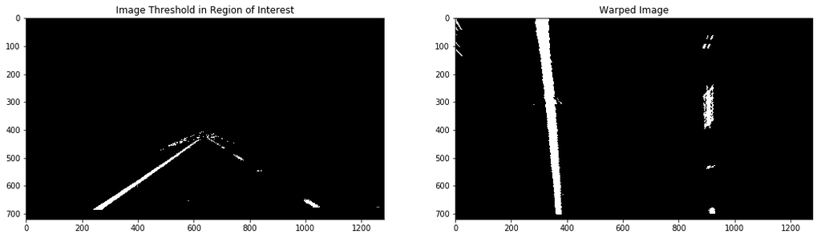

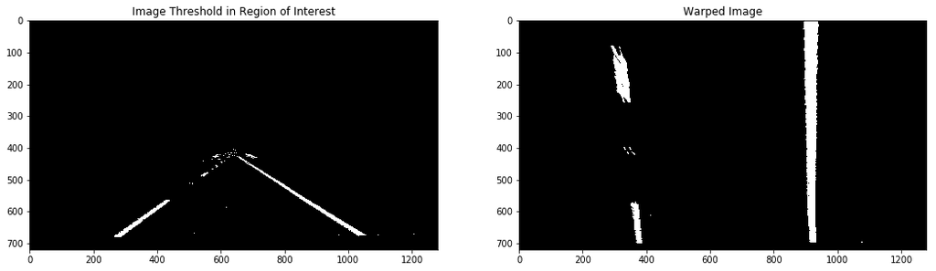

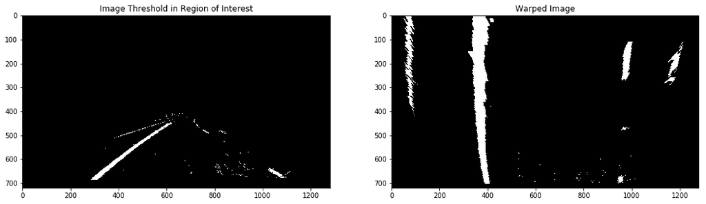

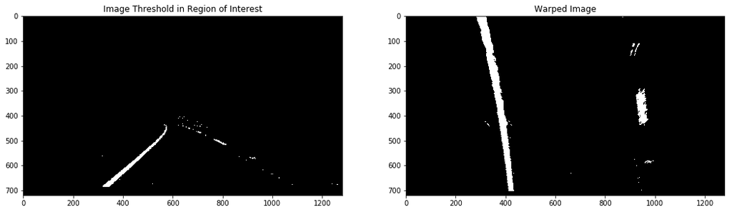

## Locate Lane Lines

#### First Instance, traverse through the entire image for highlights and determine the lines

#### Second Instance onwards, use the previous knowledge and search in restricted area

The following pipeline determines the Lane Lines in the Warped Image which is the BirdEye's view of the image in the regoin of interest.

#### function locate_lines

The Warped Image is first converted to a histogram which is done by summing up the pixel values along the columns in the bottom half of the image(top half is mostly the sky and unwanted data)

Using the histogram, it is easy to determine where the lane liines are - which are the peaks in the left half and the right half of the image

Once these are determined, the approach of window slicing is used (as explained in Chapter 15). The image is divided into n number of equal slices, and in each slice, the highest peaks are determined which form the lane lines in that slice. This process is repeated and a 2-degree polynomial is fit to the resulting points which form the lane lines.

You might think that the lines are already there, why to determine again - this is because we might have dashed lines on the road and it is important to draw a continous line.

#### function locate_lines_restricted

We don't have to repeat the above process of traversing through the whole image everytime because the lane lines in each subsequent frame of a video feed doesn't change much compared to its previous frame(note there are 24 frames per second in a regular video feed). Hence from the 2nd frame onwards, we will only do a search in a very constrained region - near to the previous resulting lane. This is done by storing the values of the left and right pixels in a class(just to memorize the previous values) and use them to search along some margin across(100 px in this case).

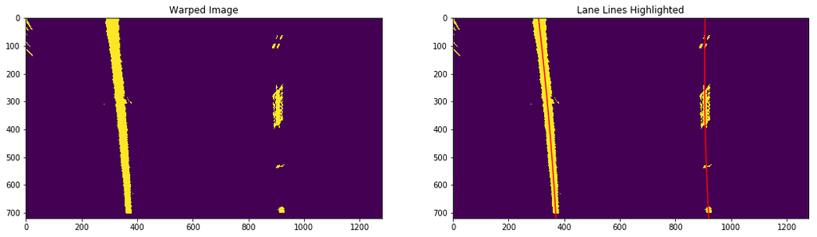

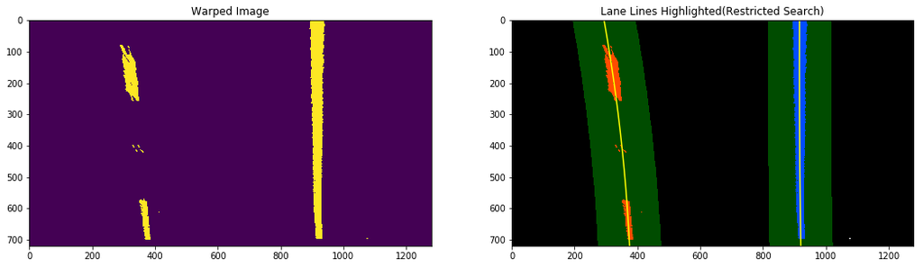

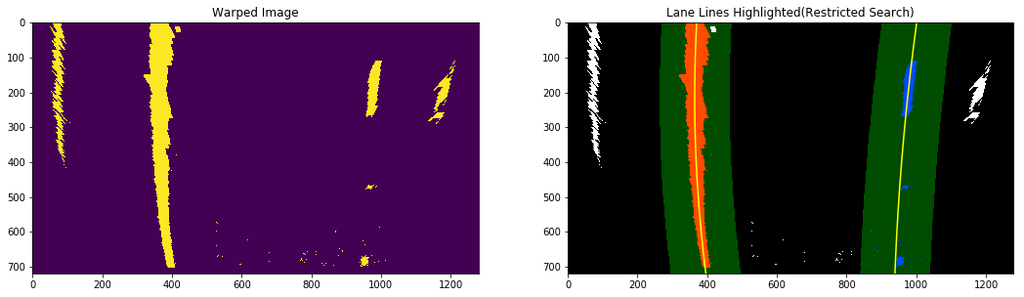

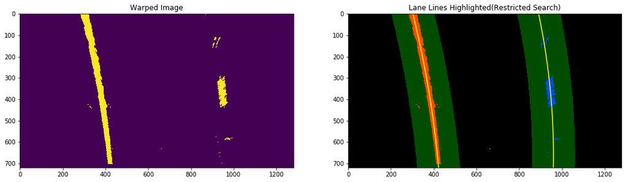

## Sanity Check

Doing a highly constrained search for the Lane lines sometimes may backfire and result in a bad result. To avoid such scenarios, it is always better to do a check if the lane lines are following certain conditions like the line being almost parallel, and the mean difference between the lines is relatively small. This will ensure we are not deviating much from the previous frame.

If, for some reason, we fall into undesired results, then we follow the first path of traversing through the whole image in slices and determining the lines

## Determining curvature

Once the lane lines are determined in the image, you can use the following formula to determine the radius of curvature.

While the derivation of the formula can be seen in Lesson 15 of Udacity CarND Term1, I'm directly giving the formula of the curvature and the derivative of the 2nd order polynomial

For the 2nd order polynomial

[figure not shown]

,

Radius of Curvature is defined as

[figure not shown]

### Displaying Output : Curvature and final Image

[output not shown]

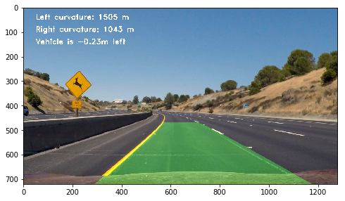

## Final processed video

After tuning all the parameters and testing on the sample image set, the code is applied on the video 'project_video.mp4'

[figure not shown]

**Improvements** The pre-processing can further be tuned to evaluate better threshold values, and various combinations of thresholding techniques

- Further tuning can be done in the color spaces - Saturation and Value color channels to make the pipeline work much effectively in shadowed regions of the video

**Lessons Learned**

- I fine-tuned various threshold values and I see that certain combination of threshold values among different gradients and color spaces work sometimes better than other values, and there is no one good-solution for this, different combinations work at different times, it is our responsibility to derive most optimum values.

### Conclusion

This concludes Term 1 Project 4 : Advanced Lane Finding use case of Udacity's Self Driving Car Nanodegree Program. While all the info about the project is already mentioned(here and in the code file), this project took me through the internals of Canny Edge detection that we used at a high level in Proj 1, and various line finding and plotting techniques